# Biostatistics III in R

Code by Johan Zetterqvist, Andreas Karlsson and Mark Clements

# Exercise 6. Diet data: tabulating incidence rates and modelling with Poisson regression

You may have to install the required packages the first time you use them. You can install a package by `install.packages("package_of_interest")` for each package you require.

```r
library(biostat3) # diet dataset
library(dplyr)    # for data manipulation
library(knitr)    # kable()
library(broom)    # tidy()
```

Load the diet data using time-on-study as the timescale. We look at the first six rows of the data using `head` and look at a summary for the variables using `summary`:

```r
head(diet) |> kable("html")
```

| id | chd | y | hieng | energy | job | month | height | weight | doe | dox | dob | yoe | yox | yob | eng3 | X1 | X2 | X3 | eng3low | eng3medium | eng3high |
| --- | --- | --- | --- | --- | --- | --- | --- | --- | --- | --- | --- | --- | --- | --- | --- | --- | --- | --- | --- | --- | --- |
| 127 | 0 | 16.791239 | low | 2023.25 | conductor | 2 | 173.9900 | 61.46280 | 1960-02-16 | 1976-12-01 | 1910-09-27 | 1960.126 | 1976.917 | 1910.737 | low | 1 | 0 | 0 | 1 | 0 | 0 |
| 200 | 0 | 19.958933 | low | 2448.68 | bank | 12 | 177.8000 | 73.48320 | 1956-12-16 | 1976-12-01 | 1909-06-18 | 1956.958 | 1976.917 | 1909.460 | low | 1 | 0 | 0 | 1 | 0 | 0 |
| 198 | 0 | 19.958933 | low | 2281.38 | bank | 12 | NA | NA | 1956-12-16 | 1976-12-01 | 1910-06-30 | 1956.958 | 1976.917 | 1910.493 | low | 1 | 0 | 0 | 1 | 0 | 0 |
| 222 | 0 | 15.394935 | low | 2467.95 | bank | 2 | 158.7500 | 58.24224 | 1957-02-16 | 1972-07-10 | 1902-07-11 | 1957.126 | 1972.523 | 1902.523 | low | 1 | 0 | 0 | 1 | 0 | 0 |
| 305 | 1 | 1.494867 | low | 2362.93 | bank | 1 | NA | NA | 1960-01-16 | 1961-07-15 | 1913-06-30 | 1960.041 | 1961.534 | 1913.493 | low | 1 | 0 | 0 | 1 | 0 | 0 |
| 173 | 0 | 15.958932 | low | 2380.11 | conductor | 12 | 164.4904 | 79.01712 | 1960-12-16 | 1976-12-01 | 1915-06-28 | 1960.958 | 1976.917 | 1915.487 | low | 1 | 0 | 0 | 1 | 0 | 0 |

```r
summary(diet) |> kable("html")
```

|  | id | chd | y | hieng | energy | job | month | height | weight | doe | dox | dob | yoe | yox | yob | eng3 | X1 | X2 | X3 | eng3low | eng3medium | eng3high |
| --- | --- | --- | --- | --- | --- | --- | --- | --- | --- | --- | --- | --- | --- | --- | --- | --- | --- | --- | --- | --- | --- | --- |
|  | Min. : 1 | Min. :0.0000 | Min. : 0.2875 | low :155 | Min. :1748 | driver :102 | Min. : 1.000 | Min. :152.4 | Min. : 46.72 | Min. :1956-11-16 | Min. :1958-08-29 | Min. :1892-01-10 | Min. :1957 | Min. :1959 | Min. :1892 | low : 75 | Min. :0.0000 | Min. :0.0000 | Min. :0.0000 | Min. :0.0000 | Min. :0.0000 | Min. :0.0000 |
|  | 1st Qu.: 85 | 1st Qu.:0.0000 | 1st Qu.:10.7762 | high:182 | 1st Qu.:2537 | conductor: 84 | 1st Qu.: 3.000 | 1st Qu.:168.9 | 1st Qu.: 64.64 | 1st Qu.:1959-01-16 | 1st Qu.:1972-09-29 | 1st Qu.:1906-01-18 | 1st Qu.:1959 | 1st Qu.:1973 | 1st Qu.:1906 | medium:150 | 1st Qu.:0.0000 | 1st Qu.:0.0000 | 1st Qu.:0.0000 | 1st Qu.:0.0000 | 1st Qu.:0.0000 | 1st Qu.:0.0000 |
|  | Median :169 | Median :0.0000 | Median :15.4606 | NA | Median :2803 | bank :151 | Median : 6.000 | Median :173.0 | Median : 72.80 | Median :1960-02-16 | Median :1976-12-01 | Median :1911-02-25 | Median :1960 | Median :1977 | Median :1911 | high :112 | Median :0.0000 | Median :0.0000 | Median :0.0000 | Median :0.0000 | Median :0.0000 | Median :0.0000 |
|  | Mean :169 | Mean :0.1365 | Mean :13.6607 | NA | Mean :2829 | NA | Mean : 6.231 | Mean :173.4 | Mean : 72.54 | Mean :1960-06-22 | Mean :1974-02-19 | Mean :1911-01-04 | Mean :1960 | Mean :1974 | Mean :1911 | NA | Mean :0.2226 | Mean :0.4451 | Mean :0.3323 | Mean :0.2226 | Mean :0.4451 | Mean :0.3323 |
|  | 3rd Qu.:253 | 3rd Qu.:0.0000 | 3rd Qu.:17.0431 | NA | 3rd Qu.:3110 | NA | 3rd Qu.:10.000 | 3rd Qu.:177.8 | 3rd Qu.: 79.83 | 3rd Qu.:1961-06-16 | 3rd Qu.:1976-12-01 | 3rd Qu.:1915-01-30 | 3rd Qu.:1961 | 3rd Qu.:1977 | 3rd Qu.:1915 | NA | 3rd Qu.:0.0000 | 3rd Qu.:1.0000 | 3rd Qu.:1.0000 | 3rd Qu.:0.0000 | 3rd Qu.:1.0000 | 3rd Qu.:1.0000 |
|  | Max. :337 | Max. :1.0000 | Max. :20.0411 | NA | Max. :4396 | NA | Max. :12.000 | Max. :190.5 | Max. :106.14 | Max. :1966-09-16 | Max. :1976-12-01 | Max. :1930-09-19 | Max. :1967 | Max. :1977 | Max. :1931 | NA | Max. :1.0000 | Max. :1.0000 | Max. :1.0000 | Max. :1.0000 | Max. :1.0000 | Max. :1.0000 |
|  | NA | NA | NA | NA | NA | NA | NA | NA’s :5 | NA’s :4 | NA | NA | NA | NA | NA | NA | NA | NA | NA | NA | NA | NA | NA |

## (a)

```r
diet <- biostat3::diet

diet.ir6a <- survRate(Surv(y/1000,chd) ~ hieng, data=diet)
kable(diet.ir6a, "html")
```

|  | hieng | tstop | event | rate | lower | upper |
| --- | --- | --- | --- | --- | --- | --- |
| hieng=low | low | 2.059430 | 28 | 13.595992 | 9.034438 | 19.64999 |
| hieng=high | high | 2.544238 | 18 | 7.074809 | 4.192980 | 11.18125 |

```r
## or
diet |>
    group_by(hieng) |>
    summarise(Event = sum(chd), Time = sum(y/1000), Rate = Event/Time,      # group sums
              lower.ci = poisson.test(Event,Time)$conf.int[1],
              upper.ci = poisson.test(Event,Time)$conf.int[2]) |> kable("html")
```

| hieng | Event | Time | Rate | lower.ci | upper.ci |
| --- | --- | --- | --- | --- | --- |
| low | 28 | 2.059430 | 13.595992 | 9.034438 | 19.64999 |
| high | 18 | 2.544238 | 7.074809 | 4.192980 | 11.18125 |

```r
## IRR
with(diet.ir6a, poisson.test(event,tstop))
```

```
##
##  Comparison of Poisson rates
##
## data:  event time base: tstop
## count1 = 28, expected count1 = 20.578, p-value = 0.03681
## alternative hypothesis: true rate ratio is not equal to 1
## 95 percent confidence interval:
##  1.026173 3.688904
## sample estimates:
## rate ratio
##   1.921747
```

```r
with(diet.ir6a, poisson.test(rev(event),rev(tstop)))
```

```
##
##  Comparison of Poisson rates
##
## data:  rev(event) time base: rev(tstop)
## count1 = 18, expected count1 = 25.422, p-value = 0.03681
## alternative hypothesis: true rate ratio is not equal to 1
## 95 percent confidence interval:
##  0.2710832 0.9744943
## sample estimates:
## rate ratio
##  0.5203599
```

We see that individuals with a high energy intake have a lower CHD incidence rate. The estimated crude incidence rate ratio is 0.52 (95% CI: 0.27, 0.97).

## (b)

The code is:

```r
poisson6b <- glm(chd ~ hieng + offset( log(y/1000)), family=poisson, data=diet)
summary(poisson6b)
```

```
##
## Call:
## glm(formula = chd ~ hieng + offset(log(y/1000)), family = poisson,
##     data = diet)
##
## Coefficients:
##             Estimate Std. Error z value Pr(>|z|)
## (Intercept)   2.6098     0.1890  13.811   <2e-16 ***
## hienghigh    -0.6532     0.3021  -2.162   0.0306 *
## ---
## Signif. codes:  0 '***' 0.001 '**' 0.01 '*' 0.05 '.' 0.1 ' ' 1
##
## (Dispersion parameter for poisson family taken to be 1)
##
##     Null deviance: 262.82  on 336  degrees of freedom
## Residual deviance: 258.00  on 335  degrees of freedom
## AIC: 354
##
## Number of Fisher Scoring iterations: 6
```

```r
eform(poisson6b)
```

```
##              exp(beta)     2.5 %     97.5 %
## (Intercept) 13.5959916 9.3877130 19.6907371
## hienghigh    0.5203599 0.2878432  0.9407012
```

```r
eform(poisson6b, method="Profile")
```

```
##              exp(beta)     2.5 %     97.5 %
## (Intercept) 13.5959916 9.1614552 19.2715805
## hienghigh    0.5203599 0.2829171  0.9328392
```

```r
## using tidyverse...
tidy(poisson6b, conf.int=TRUE, exponentiate=TRUE)
```

```
## # A tibble: 2 × 7
##   term        estimate std.error statistic  p.value conf.low conf.high
##   <chr>          <dbl>     <dbl>     <dbl>    <dbl>    <dbl>     <dbl>
## 1 (Intercept)   13.6       0.189     13.8  2.20e-43    9.16     19.3
## 2 hienghigh      0.520     0.302     -2.16 3.06e- 2    0.283     0.933
```

The point estimate for the IRR calculated by the Poisson regression is the same as the IRR calculated in 6(a). The regression model can be defined by:

$$\begin{align*}
E(\text{chd}) &= \frac{y}{1000}\exp\left(\beta_0 +
\beta_1I(\text{hieng}="high") \right) \\
&= \exp\left(\beta_0 + \beta_1I(\text{hieng}="high") +
\log(y/1000) \right)
\end{align*}$$

where $E(\text{chd})$ is the expected count for CHD, $\beta_0$ is the intercept parameter for the log rate and $\beta_1$ is the parameter for the log rate ratio for high energy diets. We have also used $I(\text{condition})$ as an indicator function, which will take a value of 1 when the condition is true and 0 otherwise.

## (c)

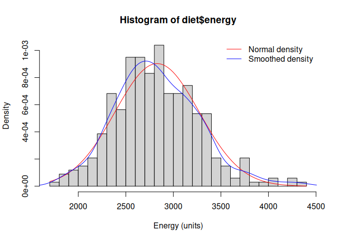

```r
hist(diet$energy, breaks=25, probability=TRUE, xlab="Energy (units)")
curve(dnorm(x, mean=mean(diet$energy), sd=sd(diet$energy)), col = "red", add=TRUE)
lines(density(diet$energy), col = "blue")
legend("topright", legend=c("Normal density","Smoothed density"),
       lty=1, col=c("red", "blue"), bty="n")
```

```r
quantile(diet$energy, probs=c(0.01,0.05,0.1,0.25,0.5,0.75,0.90,0.95,0.99))
```

```
##       1%       5%      10%      25%      50%      75%      90%      95%      99%
## 1887.268 2177.276 2314.114 2536.690 2802.980 3109.660 3365.644 3588.178 4046.820
```

```r
# For kurtosis and skewness, see package e1071
```

The histogram and density curve gives us an idea of the distribution of energy intake. The normal curve suggests that a normal approximation may be acceptable. We can also tabulate moments and percentiles of the distribution.

## (d)

```r
diet <- transform(diet, eng3=cut(energy, breaks=c(1500,2500,3000,4500),
                                 labels=c("low","medium","high"),
                                 right = FALSE))
cbind(Freq=table(diet$eng3),
      Prop=proportions(table(diet$eng3))) |> kable("html")
```

|  | Freq | Prop |
| --- | --- | --- |
| low | 75 | 0.2225519 |
| medium | 150 | 0.4451039 |
| high | 112 | 0.3323442 |

This could also be done using `dplyr::mutate`.

## (e)

```r
## rates and IRRs
diet.ir6e <- survRate(Surv(y/1000,chd) ~ eng3, data=diet)
print(diet.ir6e)
```

```
##               eng3     tstop event      rate    lower     upper
## eng3=low       low 0.9466338    16 16.901995 9.660951 27.447781
## eng3=medium medium 2.0172621    22 10.905871 6.834651 16.511619
## eng3=high     high 1.6397728     8  4.878725 2.106287  9.613033
```

```r
# calculate IRR and confidence intervals
with(diet.ir6e, rate[eng3=="medium"] / rate[eng3=="low"])
```

```
## [1] 0.6452416
```

```r
with(diet.ir6e[c(2,1),], { # compare second row with first row
  poisson.test(event, tstop)
})
```

```
##
##  Comparison of Poisson rates
##
## data:  event time base: tstop
## count1 = 22, expected count1 = 25.863, p-value = 0.2221
## alternative hypothesis: true rate ratio is not equal to 1
## 95 percent confidence interval:
##  0.3237007 1.3143509
## sample estimates:
## rate ratio
##  0.6452416
```

```r
with(diet.ir6e, rate[eng3=="high"] / rate[eng3=="low"])
```

```
## [1] 0.2886479
```

```r
with(diet.ir6e[c(3,1),], { # compare third row with first row
  poisson.test(event, tstop)
})
```

```
##
##  Comparison of Poisson rates
##
## data:  event time base: tstop
## count1 = 8, expected count1 = 15.216, p-value = 0.004579
## alternative hypothesis: true rate ratio is not equal to 1
## 95 percent confidence interval:
##  0.1069490 0.7148284
## sample estimates:
## rate ratio
##  0.2886479
```

We see that the CHD incidence rate decreases as the level of total energy intake increases. These calculations are usually better done using a regression model as they are less fiddly and can be adjusted for other covariates.

## (f)

```r
diet <- transform(diet,
                  X1 = as.numeric(eng3 == "low"),
                  X2 = as.numeric(eng3 == "medium"),
                  X3 = as.numeric(eng3 == "high"))
## or (names eng3low, eng3medium and eng3high)
diet = cbind(diet, model.matrix(~eng3+0, diet))
colSums(diet[c("X1","X2","X3","eng3low","eng3medium","eng3high")])
```

```
    X1         X2         X3    eng3low eng3medium   eng3high
    75        150        112         75        150        112
```

## (g)

```r
subset(diet, eng3=="low", select=c(energy,eng3,X1,X2,X3)) |> head() |> kable("html")
```

| energy | eng3 | X1 | X2 | X3 |
| --- | --- | --- | --- | --- |
| 2023.25 | low | 1 | 0 | 0 |
| 2448.68 | low | 1 | 0 | 0 |
| 2281.38 | low | 1 | 0 | 0 |
| 2467.95 | low | 1 | 0 | 0 |
| 2362.93 | low | 1 | 0 | 0 |
| 2380.11 | low | 1 | 0 | 0 |

```r
subset(diet, eng3=="medium", select=c(energy,eng3,X1,X2,X3)) |> head() |> kable("html")
```

|  | energy | eng3 | X1 | X2 | X3 |
| --- | --- | --- | --- | --- | --- |
| 76 | 2664.64 | medium | 0 | 1 | 0 |
| 77 | 2533.33 | medium | 0 | 1 | 0 |
| 78 | 2854.08 | medium | 0 | 1 | 0 |
| 79 | 2673.77 | medium | 0 | 1 | 0 |
| 80 | 2766.88 | medium | 0 | 1 | 0 |
| 81 | 2586.69 | medium | 0 | 1 | 0 |

```r
subset(diet, eng3=="high", select=c(energy,eng3,X1,X2,X3)) |> head() |> kable("html")
```

|  | energy | eng3 | X1 | X2 | X3 |
| --- | --- | --- | --- | --- | --- |
| 226 | 3067.36 | high | 0 | 0 | 1 |
| 227 | 3298.95 | high | 0 | 0 | 1 |
| 228 | 3147.60 | high | 0 | 0 | 1 |
| 229 | 3180.47 | high | 0 | 0 | 1 |
| 230 | 3045.81 | high | 0 | 0 | 1 |
| 231 | 3060.03 | high | 0 | 0 | 1 |

## (h)

```r
poisson6h <- glm(chd ~ X2 + X3 + offset(log(y/1000)), family=poisson, data=diet)
summary(poisson6h)
```

```
##
## Call:
## glm(formula = chd ~ X2 + X3 + offset(log(y/1000)), family = poisson,
##     data = diet)
##
## Coefficients:
##             Estimate Std. Error z value Pr(>|z|)
## (Intercept)   2.8274     0.2500  11.312  < 2e-16 ***
## X2           -0.4381     0.3285  -1.334  0.18233
## X3           -1.2425     0.4330  -2.870  0.00411 **
## ---
## Signif. codes:  0 '***' 0.001 '**' 0.01 '*' 0.05 '.' 0.1 ' ' 1
##
## (Dispersion parameter for poisson family taken to be 1)
##
##     Null deviance: 262.82  on 336  degrees of freedom
## Residual deviance: 253.62  on 334  degrees of freedom
## AIC: 351.62
##
## Number of Fisher Scoring iterations: 6
```

```r
tidy(poisson6h, conf.int=TRUE, exponentiate=TRUE)
```

```
## # A tibble: 3 × 7
##   term        estimate std.error statistic  p.value conf.low conf.high
##   <chr>          <dbl>     <dbl>     <dbl>    <dbl>    <dbl>     <dbl>
## 1 (Intercept)   16.9       0.250     11.3  1.15e-29    9.91     26.6
## 2 X2             0.645     0.329     -1.33 1.82e- 1    0.341     1.25
## 3 X3             0.289     0.433     -2.87 4.11e- 3    0.117     0.656
```

Level 1 of the categorized total energy is the reference category. The estimated rate ratio comparing level 2 to level 1 is 0.6452 and the estimated rate ratio comparing level 3 to level 1 is 0.2886.

The regression equation can be represented by:

$$\begin{align*}
E(\text{chd}) &= \frac{y}{1000}\exp\left(\beta_0 + \beta_2 X_2 +
\beta_3 X_3 \right) \\
&= \exp\left(\beta_0 + \beta_2 X_2 + \beta_3 X_3 + \log(y/1000)
\right)
\end{align*}$$
where $\beta_2$ and $\beta_3$ are the log rate ratios for $X_2=\text{X2}$ and $X_3=\text{X3}$, respectively.

## (i)

```r
poisson6i <- glm(chd ~ X1 + X3 + offset(log(y/1000)), family=poisson, data=diet)
# or
poisson6i <- glm(chd ~ I(eng3=="low") + I(eng3=="high") + offset(log(y/1000)),
                 family=poisson, data=diet)
summary(poisson6i)
```

```
##
## Call:
## glm(formula = chd ~ I(eng3 == "low") + I(eng3 == "high") + offset(log(y/1000)),
##     family = poisson, data = diet)
##
## Coefficients:
##                       Estimate Std. Error z value Pr(>|z|)
## (Intercept)             2.3893     0.2132  11.207   <2e-16 ***
## I(eng3 == "low")TRUE    0.4381     0.3285   1.334   0.1823
## I(eng3 == "high")TRUE  -0.8044     0.4129  -1.948   0.0514 .
## ---
## Signif. codes:  0 '***' 0.001 '**' 0.01 '*' 0.05 '.' 0.1 ' ' 1
##
## (Dispersion parameter for poisson family taken to be 1)
##
##     Null deviance: 262.82  on 336  degrees of freedom
## Residual deviance: 253.62  on 334  degrees of freedom
## AIC: 351.62
##
## Number of Fisher Scoring iterations: 6
```

```r
tidy(poisson6i, conf.int=TRUE, exponentiate=TRUE)
```

```
## # A tibble: 3 × 7
##   term                      estimate std.error statistic  p.value conf.low conf.high
##   <chr>                        <dbl>     <dbl>     <dbl>    <dbl>    <dbl>     <dbl>
## 1 "(Intercept)"               10.9       0.213     11.2  3.77e-29    6.96     16.1
## 2 "I(eng3 == \"low\")TRUE"     1.55      0.329      1.33 1.82e- 1    0.800     2.94
## 3 "I(eng3 == \"high\")TRUE"    0.447     0.413     -1.95 5.14e- 2    0.187     0.966
```

Now use level 2 as the reference (by omitting X2 but including X1 and X3). The estimated rate ratio comparing level 1 to level 2 is 1.5498 and the estimated rate ratio comparing level 3 to level 2 is 0.4473.

## (j)

```r
poisson6j <- glm(chd ~ eng3 + offset(log(y/1000)), family=poisson, data=diet)
summary(poisson6j)
```

```
##
## Call:
## glm(formula = chd ~ eng3 + offset(log(y/1000)), family = poisson,
##     data = diet)
##
## Coefficients:
##             Estimate Std. Error z value Pr(>|z|)
## (Intercept)   2.8274     0.2500  11.312  < 2e-16 ***
## eng3medium   -0.4381     0.3285  -1.334  0.18233
## eng3high     -1.2425     0.4330  -2.870  0.00411 **
## ---
## Signif. codes:  0 '***' 0.001 '**' 0.01 '*' 0.05 '.' 0.1 ' ' 1
##
## (Dispersion parameter for poisson family taken to be 1)
##
##     Null deviance: 262.82  on 336  degrees of freedom
## Residual deviance: 253.62  on 334  degrees of freedom
## AIC: 351.62
##
## Number of Fisher Scoring iterations: 6
```

```r
tidy(poisson6j, conf.int=TRUE, exponentiate=TRUE)
```

```
## # A tibble: 3 × 7
##   term        estimate std.error statistic  p.value conf.low conf.high
##   <chr>          <dbl>     <dbl>     <dbl>    <dbl>    <dbl>     <dbl>
## 1 (Intercept)   16.9       0.250     11.3  1.15e-29    9.91     26.6
## 2 eng3medium     0.645     0.329     -1.33 1.82e- 1    0.341     1.25
## 3 eng3high       0.289     0.433     -2.87 4.11e- 3    0.117     0.656
```

The estimates are identical (as we would hope) when we have R create indicator variables for us.

## (k)

Somehow (there are many different alternatives) you’ll need to calculate the total number of events and the total person-time at risk and then calculate the incidence rate as events/person-time. As examples,

```r
summarise(diet, rate = sum(chd) / sum(y))
```

```
##          rate
## 1 0.009992031
```

```r
## or
survRate(Surv(y/1000,chd)~1, data=diet)
```

```
##      tstop event     rate    lower    upper
## 1 4.603669    46 9.992031 7.315422 13.32797
```

The estimated incidence rate is 0.00999 events per person-year.